# LAB5 - CSM - ESTI019-17SA

Alunos:

1. João Vitor Garrido - RA: 11201811064
2. Gabriel de Oliveira Souza - RA: 11201811094
3. Victor Gabriel Ferreira dos Santos - RA: 11201811459

# ESTI019 - CSM - QS2021

LAB5 - Percepção Auditiva e Básico de Áudio

# Introdução - LAB5 - Percepção Auditiva e Básico de Áudio

Neste laboratório, foram realizados testes de audiometria, faixa audível e mascaramento de frequências, visando explorar os aspectos da percepção auditiva de todos os integrantes do grupo.

Dentre as atividades de percepção desenvolvidas, foi possível atingir os seguintes objetivos:

1. Constatar as características psicoacústicas de pessoas distintas de sensibilidade à intensidade, banda audível e mascaramento harmônico;
2. Efetuar alguns procedimentos de medição e aferição acústicos e depois analisá-los.

# 2. Teste de Audiometria

## Integrante 1 - Gabriel

Abaixo, temos o resultado do padrão audiométrico de ambas as orelhas, utilizando fone de ouvido, do integrante 1:

```python
HTML(f'<iframe src="https://gabrielsouza-oss.github.io/CSM/labs/Lab5_PERFIL/Com_Fone_Gab.pdf" width=100% height=800></iframe>')
```

[interactive chart not shown]

Abaixo, temos o resultado do padrão audiométrico de ambas as orelhas, sem fone de ouvido, do integrante 1:

```python
HTML(f'<iframe src="https://gabrielsouza-oss.github.io/CSM/labs/Lab5_PERFIL/Sem_Fone_Gab.pdf" width=100% height=800></iframe>')
```

[interactive chart not shown]

## Integrante 2 - Victor

Abaixo, temos o resultado do padrão audiométrico de ambas as orelhas, utilizando fone de ouvido, do integrante 2:

```python
HTML(f'<iframe src="https://gabrielsouza-oss.github.io/CSM/labs/Lab5_PERFIL/Lab3_comFone_Victor.pdf" width=100% height=800></iframe>')
```

[interactive chart not shown]

```python
HTML(f'<iframe src="https://gabrielsouza-oss.github.io/CSM/labs/Lab5_PERFIL/Lab3_semFone_Victor.pdf" width=100% height=800></iframe>')
```

[interactive chart not shown]

## Integrante 3 - João

Abaixo, temos o resultado do padrão audiométrico de ambas as orelhas, utilizando fone de ouvido, do integrante 3:

```python
HTML(f'<iframe src="https://gabrielsouza-oss.github.io/CSM/labs/Lab5_PERFIL/comfone_Joao.pdf" width=100% height=800></iframe>')
```

[interactive chart not shown]

Abaixo, temos o resultado do padrão audiométrico de ambas as orelhas, sem fone de ouvido, do integrante 3:

```python
HTML(f'<iframe src="https://gabrielsouza-oss.github.io/CSM/labs/Lab5_PERFIL/semfone_Joao.pdf" width=100% height=800></iframe>')
```

[interactive chart not shown]

## Conclusões

Em termos gerais, os 3 integrantes do grupo tiveram resultados melhores com fone de ouvido.

Acreditamos que o resultado sofre grande influência do ruído externo e da qualidade dos equipamentos utilizados no teste.

Excepcionalmente, o integrante Victor, apresentou uma ligeira melhoria na audição das frequências mais altas, sem o fone de ouvido, nas frequências (2k,4k e 8k).

Este resultado contraintuitivo, se deu por conta da qualidade do equipamento utilizado pelo integrante.

# 3. Teste de Faixa Audível

## a) Leia as instruções de ajuste de volume, mas não precisa usar ainda os fones de ouvido, do site em “Mostrar mais”, ajuste o volume conforme indicado, e anote a frequência mínima audível ($fa_{MIN}$) e a frequência máxima audível ($fa_{MAX}$).

1 - Gabriel:

$fa_{MIN} = 50 Hz$

$fa_{MAX} = 17.2 kHz$

2 - Victor:

$fa_{MIN} = 200 Hz$

$fa_{MAX} = 15.8 kHz$

3 - João:

$fa_{MIN} = 60 Hz$

$fa_{MAX} = 17 kHz$

## b) Apesar do nível do sinal ser sempre o mesmo, as frequências em que lhe parecer que o som é muito baixo e, também, onde parece que ele sobe mais.

João: O som parece ser mais baixo nas frequências próximas à 60 Hz e 16 kHz, com aumento em cerca de 4 kHz, mais alto nas frequências próximas de 8 kHz e decaimento em cerca de 13 kHz.

Gabriel: Senti que o volume é alto próximo da frequência de 8 kHz, sendo que este aumento se dá a partir da frequência de 5 kHz. Sinto que entre as frequências de 13 Hz e 60 Hz o volume é bem baixo.

Victor: Senti um aumento no volume em frequências próximas à 7 kHz, antes disso o volume estava bem baixo, sendo, posteriormente, a mais alta entre 8 kHz e 9 kHz, voltando a diminuir perto de 13 kHz, e mais baixas depois disso.

## c) Repita o procedimento com um fone de ouvido, normal ou envolvente

1 - Gabriel:

$fa_{MIN} = 50 Hz$

$fa_{MAX} = 17.2 kHz$

2 - Victor:

$fa_{MIN} = 52 Hz$

$fa_{MAX} = 15 kHz$

3 - João:

$fa_{MIN} = 60 Hz$

$fa_{MAX} = 17 kHz$

## d) Repita o procedimento com o seu aparelho celular, sem fone de ouvido

1 - Gabriel:

$fa_{MIN} = 65 Hz$

$fa_{MAX} = 17.1 kHz$

2 - Victor:

$fa_{MIN} = 61 Hz$

$fa_{MAX} = 15,9 kHz$

3 - João:

$fa_{MIN} = 60 Hz$

$fa_{MAX} = 17 kHz$

## e) Por que ocorrem as diferenças?

Em relação ao equipamento utilizado nos testes, notamos que nos fones de ouvido, os ouvidos são colocados muito perto da montagem dos drivers. Em geral, isso significa que somos capazes de ouvir mais detalhes e nuances quando comparamos com os alto-falantes do celular, mesmo em faixas familiares.

Quanto às diferenças entre os integrantes, estão associadas tanto aos diferentes equipamentos de aúdio utilizados por cada um, quanto aos diferentes perfis audiométricos, observados no item 1.

# 4. Mascaramento de Frequências

## a-) & b-)

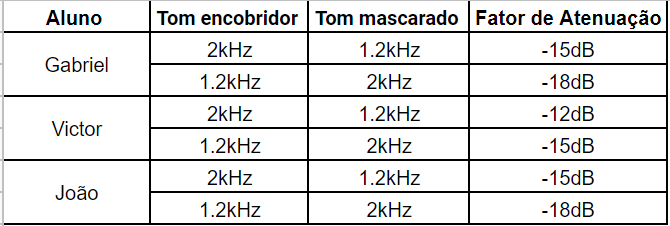

Notamos que os integrantes Gabriel e João, precisaram de um maior fator de atenuação para que as frequências fossem completamente mascaradas, relativamente ao integrante Victor.

Este fato revela que talvez os dois integrantes sejam mais sensíveis às frequências intermediárias de 1.2Hz e 2Hz

## c-)

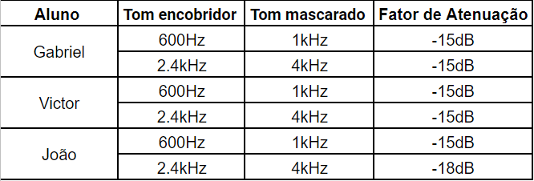

Neste teste, notamos que os três integrantes apresentaram aproxidamente, o mesmo fator de atenuação com as frequências oitavadas, sugerindo que talvez estas frequências sejam similarmente percebidas entre os integrantes

# 5. Conclusões

## b-) Escreva as conclusões sobre os aspectos psicoacústicos para CADA um dos integrantes do grupo.

2 - Victor:

Durante a realização do experimento, fui capaz de notar as múltiplas variáveis que devem ser contabilizadas ao se realizar um teste psicoacústico, como ambiente, equipamento e estado mental. Os resultados me deram uma boa compreensão dos espectros de som audiveis pelo ser humano, sendo capaz de comparar meu resultado com o dos demais integrantes.

3 - João:

Conforme a proposta do laboratório, foi possível colocar os limites da audição humana à prova através de diversos experimentos psicoacústicos. Além disso, dado que o experimento foi reproduzido pelos demais companheiros de grupo, também foi possível verificar que as diferenças entre os sistemas auditivos são facilmente influenciadas por fatores externos, tais como o ambiente em que se está sendo realizado o experimento, os equipamentos, entre outros. A partir deste estudo, tivemos a oportunidade de compreender melhor o comportamento do nosso sistema, explorando diferentes faixas de frequência audíveis.

## c-) Descrever outro teste psicoacústico que não foi realizado nesta experiência.

**Funções de perda psicoacústica para codificação de áudio neural**

A codificação de áudio neural é uma área em que queremos compactar um sinal de áudio até um bitstring, que deve ser recuperado como outro sinal de áudio que soe o mais semelhante possível aos ouvidos humanos, é claro, usando redes neurais. Esse objetivo não é tão direto quando se trata de treinar uma rede neural que faz esse trabalho de autencodificação , porque o que acabei de dizer na frase anterior não está bem definido como uma função de perda diferenciável.

O codificador de áudio neural, como um modelo de Machine Learning, pode ser treinado como uma função paramétrica, cuja predição (no caso da codificação a reconstrução do sinal de entrada) deve ser o mais semelhante possível ao alvo (o sinal de entrada antes da compressão). Se forem diferentes, a diferença é contabilizada como perda , cuja diferenciação é propagada de volta para a rede para atualização dos parâmetros. A questão complicada está aqui: diferente? Diferente como?

A perda entre os dois sinais pode ser calculada de várias maneiras: erro quadrático médio entre as amostras no domínio do tempo, comparação no domínio da frequência, tirar o log ou não, etc. No entanto, nenhum deles é perfeito, porque a percepção auditiva humana é altamente subjetivo e difícil de quantificar. Por exemplo, mesmo um par significativamente diferente, em termos de erro médio quadrático, pode soar indistinguivelmente semelhante a um sujeito humano e vice-versa. Tem havido alguns esforços para chegar a uma função de perda mais razoável que se alinhe melhor com a percepção auditiva humana, mas eles são um tanto primitivos, e nem tanto trabalho foi feito para codificação de áudio neural. Portanto, nosso objetivo é chegar a uma função de perda melhor baseada em psicoacústica adequada, que pode fazer os codificadores de áudio neurais competirem com os codificadores tradicionais.

## d-)Indique um trabalho que aborde algum novo resultado de percepção psicoacústica ainda não abordado nas aulas, colocando um hyperlink no site.

https://saige.sice.indiana.edu/research-projects/pam-nac/